# Support Vector Machines in R

For DATA50XX by ctong

## Overview

**Support Vector Machines (SVMs)** are supervised learning models used for both classification and regression tasks. At their core, SVMs aim to find the optimal hyperplane to serve as a decision boundary to best separate observations into different classes.

### Margin and Support Vectors

Margin is defined as the distance between the decision boundary (the separating hyperplane) and the closest data points from each class. These closest points are called support vectors. They directly influence the position and orientation of the hyperplane.

*Example: A 2D separating hyperplane is line*

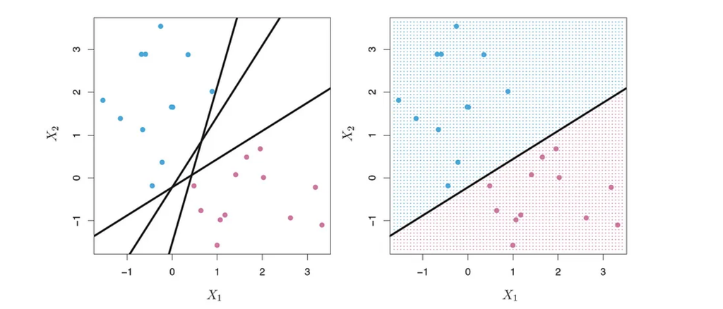

### Hard versus Soft Margins

**Hard Margin**: Applies when data is perfectly linearly separable. SVM finds the hyperplane that maximizes the margin without any misclassifications. A wider margin produces a more robust with improved generalization to unseen data.

**Soft Margin**: Allows for some misclassifications to accommodate noisy and overlapping data. A penalty parameter controls the trade-off between maximizing margin and minimizing misclassifications.

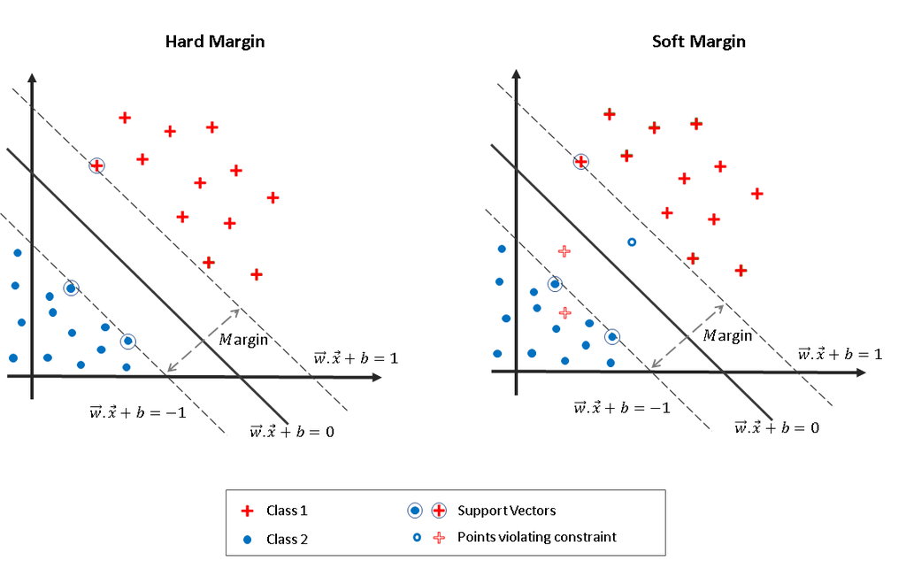

### Kernel Functions

**Kernel Functions** transform data into a higher-dimensional space to make observations of different class more easily separable by a hyperplane.

*Example: 1D to 2D*

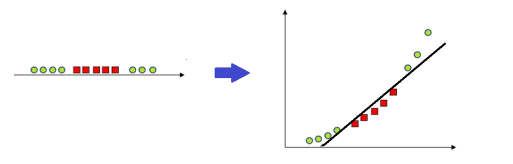

*Example: 2D to 3D*

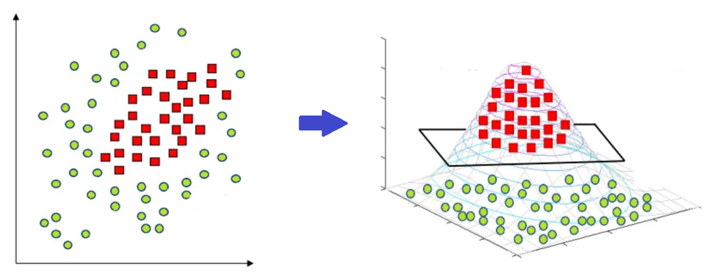

### Kernel Trick

Computation of similarity measures in high-dimensional space for determining decision boundary without explicitly transforming the data, saving computational resources.

### Similarity

Similarity is measured using mathematical functions related to distance between the data points. A **high similarity** value means the points are close together, while a **low similarity** means they are far apart.

When a kernel function is applied, SVM builds its model using **pairwise similarities** rather than raw feature values. This emulates the transformation of non-linearly separable data into a higher dimensional space for computing a separating hyperplane (decision boundary) without actually transforming the data.

For example, the **Radial Basis Function (RBF) kernel** computes similarity as:

$$K(x, x') = \exp(-\gamma \|x -
x'\|^2)$$

- If `x` and `x'` are very similar (i.e., close), the computed value is close to **1**.
- If they are very different (far apart), the computed value is close to **0**.

The positioning of the decision boundary is influenced only by the most critical points (support vectors) through their similarity to other data points. If a support vector is similar to many nearby points, the model will rely more heavily on that SV to determine where the boundary should go. In other words, similarity values help determine the shape and position of the decision boundary.

### Classification versus Regression

- **SVM Classification**: Finds a boundary that best separates classes.
- **SVM Regression (SVR)**: Tries to fit the best possible line (or curve) that stays within an acceptable error margin from the actual data points.

## Linear Kernel

A linear kernel assumes the data can be separated using a straight line (or hyperplane). It is best suited for linearly separable data.

```r
library(caret)
library(kernlab)
library(e1071)

data(iris)

## Only use 2 classes for binary classification
iris_binary <- subset(iris, Species != "setosa")
iris_binary$Species <- factor(iris_binary$Species)

## Set up cross-validation
ctrl <- trainControl(method = "cv", number = 5)

## Train linear SVM
set.seed(123)
svm_linear <- train(Species ~ Petal.Length + Petal.Width, data = iris_binary,
                    method = "svmLinear",
                    trControl = ctrl,
                   tuneLength=5)

svm_linear
```

```
## Support Vector Machines with Linear Kernel
##
## 100 samples
##   2 predictor
##   2 classes: 'versicolor', 'virginica'
##
## No pre-processing
## Resampling: Cross-Validated (5 fold)
## Summary of sample sizes: 80, 80, 80, 80, 80
## Resampling results:
##
##   Accuracy  Kappa
##   0.93      0.86
##
## Tuning parameter 'C' was held constant at a value of 1
```

```r
svm_linear$finalModel
```

```
## Support Vector Machine object of class "ksvm"
##
## SV type: C-svc  (classification)
##  parameter : cost C = 1
##
## Linear (vanilla) kernel function.
##
## Number of Support Vectors : 19
##
## Objective Function Value : -14.6831
## Training error : 0.06
```

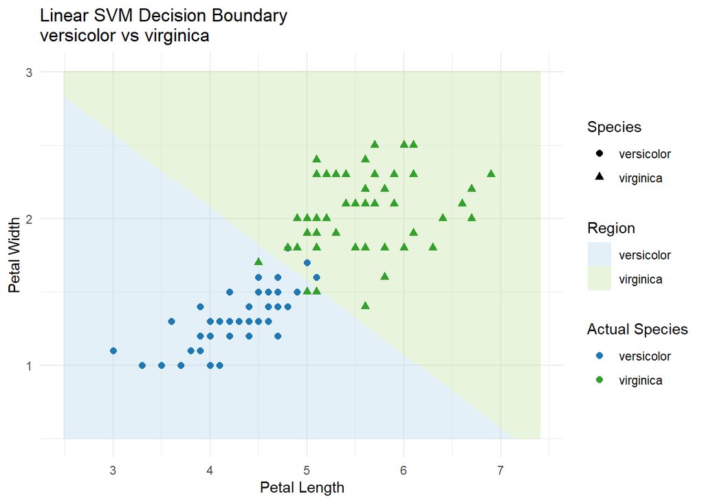

```r
pl_range <- seq(min(iris_binary$Petal.Length) - 0.5, max(iris_binary$Petal.Length) + 0.5, length = 200)
pw_range <- seq(min(iris_binary$Petal.Width)  - 0.5, max(iris_binary$Petal.Width)  + 0.5, length = 200)
grid <- expand.grid(Petal.Length = pl_range, Petal.Width = pw_range)

# 5. Predict class on the grid
grid$Predicted <- predict(svm_linear, newdata = grid)

# 6. Plot data and decision regions
ggplot() +
  # background colored by predicted class
  geom_tile(data = grid, aes(x = Petal.Length, y = Petal.Width, fill = Predicted), alpha = 0.3) +
  # original points on top
  geom_point(data = iris_binary, aes(x = Petal.Length, y = Petal.Width, shape = Species, color = Species), size = 2) +
  scale_fill_manual(values = c("versicolor" = "#A6CEE3", "virginica" = "#B2DF8A")) +
  scale_color_manual(values = c("versicolor" = "#1F78B4", "virginica" = "#33A02C")) +
  labs(
    title = "Linear SVM Decision Boundary\nversicolor vs virginica",
    x = "Petal Length",
    y = "Petal Width",
    fill = "Region",
    color = "Actual Species"
  ) +
  theme_minimal()
```

### Hyperparameters

- **C (Cost)**: Controls the trade-off between margin size and classification error. Lower values allow a larger margin but more errors.

### Interpreting Output

- **Accuracy**: Proportion of correctly classified samples in cross-validation.
- **Best Tune**: Shows which value of C yielded the best performance.

## Polynomial Kernel

Polynomial kernels allow modeling more complex boundaries by considering interactions of features up to a specified degree.

```r
set.seed(123)
svm_poly <- train(Species ~ ., data = iris_binary,
                  method = "svmPoly",
                  trControl = ctrl,
                  tuneLength = 5)

svm_poly
```

```
## Support Vector Machines with Polynomial Kernel
##
## 100 samples
##   4 predictor
##   2 classes: 'versicolor', 'virginica'
##
## No pre-processing
## Resampling: Cross-Validated (5 fold)
## Summary of sample sizes: 80, 80, 80, 80, 80
## Resampling results across tuning parameters:
##
##   degree  scale  C     Accuracy  Kappa
##   1       1e-03  0.25  0.88      0.76
##   1       1e-03  0.50  0.88      0.76
##   1       1e-03  1.00  0.88      0.76
```

[output cut: 75 more lines]

### Hyperparameters

- **Degree**: The polynomial degree.
- **Scale**: Scaling parameter.
- **C (Cost)**: Controls the trade-off between margin size and classification error. Lower values allow a larger margin but more errors.

### Interpreting Output

Look for the best combination of degree, scale, and cost that yields highest cross-validated accuracy.

## RBF Kernel

The Radial Basic Function (RBF) handles non-linear boundaries by using a bell-shaped function to measure similarity.

```r
set.seed(123)
svm_rbf <- train(Species ~ ., data = iris_binary,
                 method = "svmRadial",
                 trControl = ctrl,
                 tuneLength = 5)

svm_rbf
```

```
## Support Vector Machines with Radial Basis Function Kernel
##
## 100 samples
##   4 predictor
##   2 classes: 'versicolor', 'virginica'
##
## No pre-processing
## Resampling: Cross-Validated (5 fold)
## Summary of sample sizes: 80, 80, 80, 80, 80
## Resampling results across tuning parameters:
##
##   C     Accuracy  Kappa
##   0.25  0.93      0.86
##   0.50  0.94      0.88
##   1.00  0.93      0.86
##   2.00  0.92      0.84
##   4.00  0.92      0.84
##
## Tuning parameter 'sigma' was held constant at a value of 0.2706581
## Accuracy was used to select the optimal model using the largest value.
## The final values used for the model were sigma = 0.2706581 and C = 0.5.
```

### Hyperparameters

- **Sigma**: Defines the radius of influence of a support vector.
- **C (Cost)**: Controls the trade-off between margin size and classification error. Lower values allow a larger margin but more errors.

### Interpreting Output

Best performance is achieved by balancing the flexibility of the model (sigma) and regularization (C).

## Support Vector Regression

SVR seeks a hyperplane (a linear function in higher dimensions, potentially achieved through a "kernel trick") that best represents the relationship between input features and the target variable. This hyperplane is essentially the line of best fit for the data, similar to linear regression, but with a key difference in how errors are handled.

The **ε-Tube**: Instead of minimizing the error between predicted and actual values directly, SVR defines a margin around the hyperplane, often called an ε-tube or "tube". The goal is to find a hyperplane that fits the data points within this ε-tube, with minimal deviations outside, i.e., Only data points outside this margin influence the model.

```r
data(cars)

ctrl_reg <- trainControl(method = "cv", number = 5)

set.seed(123)
svr_rbf <- train(Mileage ~ Cylinder, data = cars,
                 method = "svmRadial",
                 trControl = ctrl_reg,
                 tuneLength = 5)

svr_rbf
```

```
## Support Vector Machines with Radial Basis Function Kernel
##
## 804 samples
##   1 predictor
##
## No pre-processing
## Resampling: Cross-Validated (5 fold)
## Summary of sample sizes: 643, 643, 642, 644, 644
## Resampling results across tuning parameters:
##
##   C     RMSE      Rsquared     MAE
##   0.25  8236.342  0.001719805  6353.786
##   0.50  8236.301  0.001719104  6353.731
##   1.00  8236.303  0.001717764  6353.726
##   2.00  8236.297  0.001719944  6353.730
##   4.00  8236.327  0.001708632  6353.791
##
## Tuning parameter 'sigma' was held constant at a value of 0.3008192
## RMSE was used to select the optimal model using the smallest value.
## The final values used for the model were sigma = 0.3008192 and C = 2.
```

### Hyperparameters

- **C**: Penalty for errors outside the epsilon-tube.
- **Epsilon**: Width of the margin of tolerance.
- **Sigma**: For radial kernel.

### Kernel Specification

In caret: - `method = "svmLinear"` for linear - `method = "svmPoly"` for polynomial - `method = "svmRadial"` for RBF

## Summary

### Comparison of SVM Kernels

This document compares Support Vector Machine (SVM) kernels—**Linear**, **Polynomial**, and **Radial Basis Function (RBF)**—in terms of their strengths, limitations, and when each is most appropriate.

### Linear Kernel

#### Pros

- Fast to compute, especially on large datasets.
- Easier to interpret due to linear decision boundary.
- Fewer hyperparameters—only regularization parameter `C`.
- Works well with high-dimensional, sparse datasets (e.g., text classification).

#### Cons

- Limited flexibility—can’t model complex non-linear boundaries.
- Risk of underfitting if the data is not linearly separable.

#### When to Use

- When the data is approximately linearly separable.
- When interpretability and speed are important.
- When working with high-dimensional or sparse data.

### Polynomial Kernel

#### Pros

- Captures interactions between features through polynomial terms.
- Tunable complexity via `degree` parameter.
- Useful when feature interactions are known to be polynomial.

#### Cons

- More computationally expensive than linear.
- More hyperparameters (`degree`, `scale`, `C`) require careful tuning.
- Can overfit, especially at high degrees.

#### When to Use

- When the relationship between features is polynomial.
- When you need a more flexible model than linear but want to avoid the full complexity of RBF.

### RBF Kernel

#### Pros

- Highly flexible and powerful for non-linear decision boundaries.
- Good accuracy across a wide variety of datasets.
- Automatically adapts to data complexity via `sigma` or `gamma`.

#### Cons

- Can overfit if not properly tuned.
- Less interpretable due to complex feature space transformations.
- Slower to train, especially on large datasets.

#### When to Use

- When data has complex, non-linear patterns.
- When prediction accuracy is prioritized over interpretability.
- When adequate computational resources are available.

### Summary Comparison Table

| Kernel Type | Pros | Cons | Best When… |
| --- | --- | --- | --- |
| **Linear** | Fast, interpretable, good with sparse data | Cannot model non-linearity | Data is linearly separable or high-dimensional |
| **Polynomial** | Captures feature interactions, moderate complexity | Slower, risk of overfitting with high degrees | Data has polynomial feature interactions |
| **RBF** | Highly flexible, best accuracy in many cases | Less interpretable, slower, tuning sensitive | Complex non-linear data, accuracy matters |

## Lab

### Exercise 1: Linear SVM

Use the `mtcars` dataset. Predict `am` (automatic/manual) using all other variables. Use a linear kernel and report accuracy.

### Exercise 2: Polynomial Kernel

Use the `Sonar` dataset from `mlbench`. Build a classifier to distinguish mines from rocks using a polynomial kernel.

### Exercise 3: RBF Kernel

Use the `Glass` dataset. Predict `Type` using an RBF kernel. Compare the performance to linear SVM.

### Exercise 4: SVR

Use the `Boston` dataset (from `MASS`) to predict `medv` using support vector regression. Try different kernels and compare RMSE.

### Questions

1. When would you choose a radial kernel over a linear one?
2. How do support vectors influence the decision boundary?
3. What happens when C is set very high?
4. In SVR, what does epsilon control?
5. Why might a linear model outperform an RBF kernel in some cases?